# Ford GoBike Data Investigation & Visualization

### QUESTION 3: What is the average trip durations?

```python
# Overall trip duration average
fb_clean.duration_sec.describe()
```

```
count    183412.000000
mean        726.078435
std        1794.389780
min          61.000000
25%         325.000000
50%         514.000000
75%         796.000000
max       85444.000000
Name: duration_sec, dtype: float64
```

Overall trip duration average is 726.078435 seconds or is about 12 minutes.

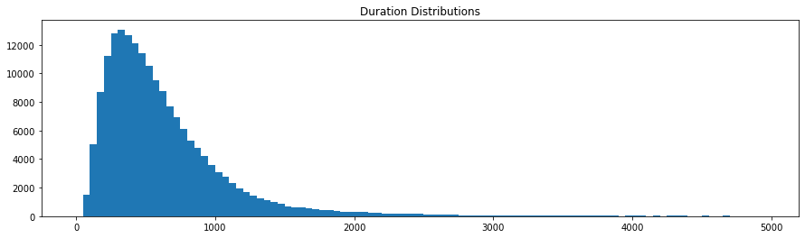

```python
plt.figure(figsize=(15,4))
bins = np.arange(0, 5000, 50)

plt.hist(fb_clean.duration_sec, bins=bins)
plt.title('Duration Distributions');
```

It shows that the distribution of duration is right skewed distribution.

### QUESTION 4: What is the Bike Distribution?

### Let see how often the bicycles get driven.

```python
#counts of each bike
bike_ride_count = fb_clean.bike_id.value_counts()
```

```python
#summary of the bike_ride_count
bike_ride_count.describe()
```

```
count    4646.000000
mean       39.477400
std        38.055172
min         1.000000
25%        12.000000
50%        26.000000
75%        55.000000
max       191.000000
Name: bike_id, dtype: float64
```

This shows the average count of bike ride is 39.477400 and the most time a bike is driven is 191 times.

### QUESTION 5: How does the Datetime affect the ride?

```python
# we need new columns for this analysis (month, start_day, end_day, and hour)
import datetime as dt
fb_clean['month'] = fb_clean['start_time'].dt.month_name()
fb_clean['start_day'] = fb_clean['start_time'].dt.day_name()
fb_clean['hour'] = fb_clean['start_time'].dt.hour

fb_clean
```

|  | duration_sec | start_time | end_time | start_station_id | start_station_name | start_station_latitude | start_station_longitude | end_station_id | end_station_name | end_station_latitude | end_station_longitude | bike_id | user_type | member_birth_year | member_gender | bike_share_for_all_trip | month | start_day | hour |
| --- | --- | --- | --- | --- | --- | --- | --- | --- | --- | --- | --- | --- | --- | --- | --- | --- | --- | --- | --- |
| 0 | 52185 | 2019-02-28 17:32:10.145 | 2019-03-01 08:01:55.975 | 21.0 | Montgomery St BART Station (Market St at 2nd St) | 37.789625 | -122.400811 | 13.0 | Commercial St at Montgomery St | 37.794231 | -122.402923 | 4902 | Customer | 1984.0 | Male | No | February | Thursday | 17 |
| 1 | 42521 | 2019-02-28 18:53:21.789 | 2019-03-01 06:42:03.056 | 23.0 | The Embarcadero at Steuart St | 37.791464 | -122.391034 | 81.0 | Berry St at 4th St | 37.77588 | -122.39317 | 2535 | Customer | NaN | NaN | No | February | Thursday | 18 |
| 2 | 61854 | 2019-02-28 12:13:13.218 | 2019-03-01 05:24:08.146 | 86.0 | Market St at Dolores St | 37.769305 | -122.426826 | 3.0 | Powell St BART Station (Market St at 4th St) | 37.786375 | -122.404904 | 5905 | Customer | 1972.0 | Male | No | February | Thursday | 12 |
| 3 | 36490 | 2019-02-28 17:54:26.010 | 2019-03-01 04:02:36.842 | 375.0 | Grove St at Masonic Ave | 37.774836 | -122.446546 | 70.0 | Central Ave at Fell St | 37.773311 | -122.444293 | 6638 | Subscriber | 1989.0 | Other | No | February | Thursday | 17 |
| 4 | 1585 | 2019-02-28 23:54:18.549 | 2019-03-01 00:20:44.074 | 7.0 | Frank H Ogawa Plaza | 37.804562 | -122.271738 | 222.0 | 10th Ave at E 15th St | 37.792714 | -122.24878 | 4898 | Subscriber | 1974.0 | Male | Yes | February | Thursday | 23 |
| ... | ... | ... | ... | ... | ... | ... | ... | ... | ... | ... | ... | ... | ... | ... | ... | ... | ... | ... | ... |
| 183407 | 480 | 2019-02-01 00:04:49.724 | 2019-02-01 00:12:50.034 | 27.0 | Beale St at Harrison St | 37.788059 | -122.391865 | 324.0 | Union Square (Powell St at Post St) | 37.7883 | -122.408531 | 4832 | Subscriber | 1996.0 | Male | No | February | Friday | 0 |
| 183408 | 313 | 2019-02-01 00:05:34.744 | 2019-02-01 00:10:48.502 | 21.0 | Montgomery St BART Station (Market St at 2nd St) | 37.789625 | -122.400811 | 66.0 | 3rd St at Townsend St | 37.778742 | -122.392741 | 4960 | Subscriber | 1984.0 | Male | No | February | Friday | 0 |
| 183409 | 141 | 2019-02-01 00:06:05.549 | 2019-02-01 00:08:27.220 | 278.0 | The Alameda at Bush St | 37.331932 | -121.904888 | 277.0 | Morrison Ave at Julian St | 37.333658 | -121.908586 | 3824 | Subscriber | 1990.0 | Male | Yes | February | Friday | 0 |
| 183410 | 139 | 2019-02-01 00:05:34.360 | 2019-02-01 00:07:54.287 | 220.0 | San Pablo Ave at MLK Jr Way | 37.811351 | -122.273422 | 216.0 | San Pablo Ave at 27th St | 37.817827 | -122.275698 | 5095 | Subscriber | 1988.0 | Male | No | February | Friday | 0 |
| 183411 | 271 | 2019-02-01 00:00:20.636 | 2019-02-01 00:04:52.058 | 24.0 | Spear St at Folsom St | 37.789677 | -122.390428 | 37.0 | 2nd St at Folsom St | 37.785 | -122.395936 | 1057 | Subscriber | 1989.0 | Male | No | February | Friday | 0 |

183412 rows × 19 columns

## Let us consider this based on Start Day.

```python
fb_clean.start_day.value_counts()
```

```
Thursday     35197
Tuesday      31813
Wednesday    29641
Friday       28981
Monday       26852
Sunday       15523
Saturday     15405
Name: start_day, dtype: int64
```

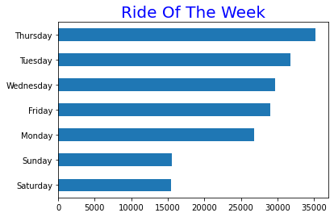

```python
plt.title('Ride Of The Week', fontsize=20, color='blue')
fb_clean.start_day.value_counts(ascending=True).plot.barh();
```

This show Thursday has the highest day ride count and saturday has the lowest day ride count, and it also show the lowest riders are on the weekends.

## QUESTION 6: How does the Stations Analysis determine ride?

Let us start by checking the list of all the stations in San Francisco.

```python
fb_clean.start_station_name.nunique()
```

```
329
```

There are 329 stationsin San Francisco Bay area.

```python
fb_clean.start_station_name.unique()
```

```
array(['Montgomery St BART Station (Market St at 2nd St)',
       'The Embarcadero at Steuart St', 'Market St at Dolores St',
       'Grove St at Masonic Ave', 'Frank H Ogawa Plaza',
       '4th St at Mission Bay Blvd S', 'Palm St at Willow St',
       'Washington St at Kearny St', 'Post St at Kearny St',
       'Jones St at Post St',
       'Civic Center/UN Plaza BART Station (Market St at McAllister St)',
       'Valencia St at 21st St', 'Channing Way at Shattuck Ave',
       'Bancroft Way at College Ave', 'Howard St at Mary St',
       '22nd St at Dolores St', 'Laguna St at Hayes St',
       '5th St at Folsom', 'Telegraph Ave at 23rd St',
       'Page St at Scott St', 'Lake Merritt BART Station',
       'West St at 40th St', 'The Embarcadero at Sansome St',
       'Folsom St at 9th St', 'University Ave at Oxford St',
       'MLK Jr Way at University Ave', 'The Embarcadero at Bryant St',
       '17th St at Valencia St', 'Valencia St at 16th St',
       'Valencia St at 22nd St', 'Franklin Square',
       'San Pablo Ave at MLK Jr Way', '19th St at Mission St',
       'Market St at 10th St', 'Folsom St at 13th St',
       'San Francisco Ferry Building (Harry Bridges Plaza)',
       '4th St at 16th St', 'Beale St at Harrison St',
       'Broadway at Battery St', 'Cesar Chavez St at Dolores St',
       'San Fernando St at 4th St', 'Grove St at Divisadero',
       'Sanchez St at 17th St', 'Harmon St at Adeline St',
       'Mission Playground', 'Davis St at Jackson St',
       'Haste St at Telegraph Ave', 'Howard St at 8th St',
       'Folsom St at 3rd St', 'Father Alfred E Boeddeker Park',
       'Commercial St at Montgomery St', 'Hubbell St at 16th St',
       'San Francisco Public Library (Grove St at Hyde St)',
       'Bancroft Way at Telegraph Ave', '19th Street BART Station',
       '18th St at Noe St', 'Hyde St at Post St', '24th St at Market St',
       'Vine St at Shattuck Ave',
       'San Francisco Caltrain (Townsend St at 4th St)',
       'Valencia St at Clinton Park',
       'Union Square (Powell St at Post St)', 'Broderick St at Oak St',
       'San Francisco Caltrain Station 2  (Townsend St at 4th St)',
       'North Berkeley BART Station', 'Downtown Berkeley BART',
       'Fell St at Stanyan St', 'San Salvador St at 9th St',
       'Marston Campbell Park', 'Oregon St at Adeline St',
       '11th St at Natoma St', 'Harrison St at 20th St',
```

[output cut: 117 more lines]

```
       'Bestor Art Park', 'College Ave at Bryant Ave',
       'Miles Ave at Cavour St', 'Saint James Park',
       '14th St at Filbert St', 'Foothill Blvd at Fruitvale Ave',
       'Market St at 8th St', 'Backesto Park (Jackson St at 13th St)',
       '10th Ave at E 15th St', 'Alcatraz Ave at Shattuck Ave',
       '55th St at Telegraph Ave', 'Genoa St at 55th St',
       'Dover St at 57th St', 'San Pablo Park',
       '6th Ave at E 12th St (Temporary Location)', 'Taylor St at 9th St',
       '27th St at MLK Jr Way', 'Foothill Blvd at Harrington Ave',
       '23rd Ave at Foothill Blvd', 'San Pedro St at Hedding St',
       '45th St at MLK Jr Way', '5th St at Taylor St',
       'Foothill Blvd at 42nd Ave', 'Willow St at Vine St',
       '26th Ave at International Blvd', 'Farnam St at Fruitvale Ave',
       '21st Ave at International Blvd', '2nd St at Folsom St'],
      dtype=object)
```

## Five most used stations

### Let us look at most used start stations first then most used end stations

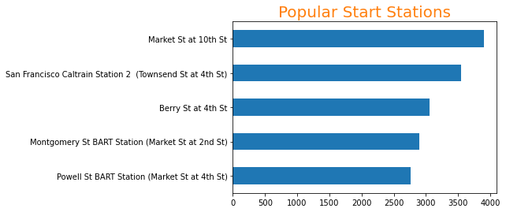

```python
plt.title('Popular Start Stations', fontsize=20, color=base_color)
fb_clean.start_station_name.value_counts(ascending=True).tail(5).plot.barh();
```

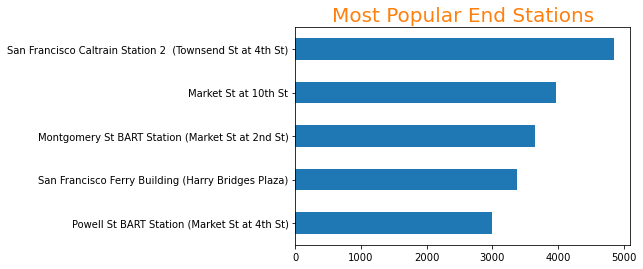

```python
plt.title('Most Popular End Stations', fontsize= 20, color=base_color)
fb_clean.end_station_name.value_counts(ascending=True).tail(5).plot.barh();
```

## Now let us see the Most 5 Popular Stations

For start station and end station, we choose five most popular station, from both, we only choose those that fall into the second group.

```python
# declare variable name for start and end stations
ride_start = fb_clean.start_station_name.value_counts(ascending=True).tail(5)
ride_end = fb_clean.end_station_name.value_counts(ascending=True).tail(5)

# station that are popular in both start and end stations
for s in ride_start.index:
    if s in ride_end:
        print(s)
```

```
Powell St BART Station (Market St at 4th St)
Montgomery St BART Station (Market St at 2nd St)
San Francisco Caltrain Station 2  (Townsend St at 4th St)
Market St at 10th St
```

### Discuss the distribution(s) of your variable(s) of interest. Were there any unusual points? Did you need to perform any transformations?

Most of the user type are the subscribers and the gender with the more ride is the Male gender, it also affects the average ride duration which is around 12 minutes.

### Of the features you investigated, were there any unusual distributions? Did you perform any operations on the data to tidy, adjust, or change the form of the data? If so, why did you do this?

Quality issues for many columns, which is the dtype is not suitable with it's data,

We have to add some column to extend our time- based analysis

## QUESTION 1: What is the correlation between trip duration and age?

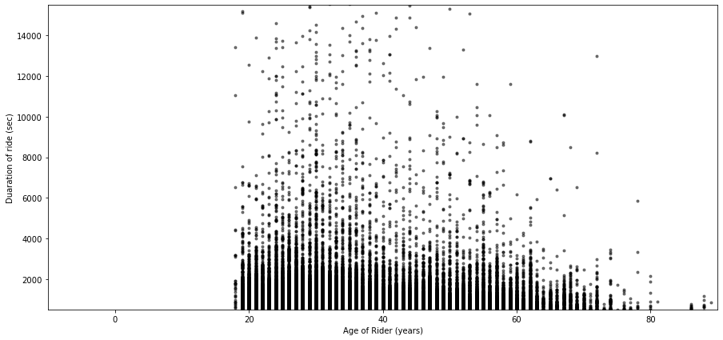

```python
plt.figure(figsize=[15,7])
plt.scatter((2019 - fb_clean['member_birth_year']), fb_clean['duration_sec'], color = 'black', alpha = 0.50, marker = '.' )
plt.axis([-10, 90, 500, 15500])
plt.xlabel('Age of Rider (years)')
plt.ylabel('Duaration of ride (sec)')
plt.show()
```

#### From these we can say that most frequent users of bikes are between 20 and 60 years of age.

## QUESTION 2:What is the Riding duration based on user type?

```
(-15.0, 3000.0)
```

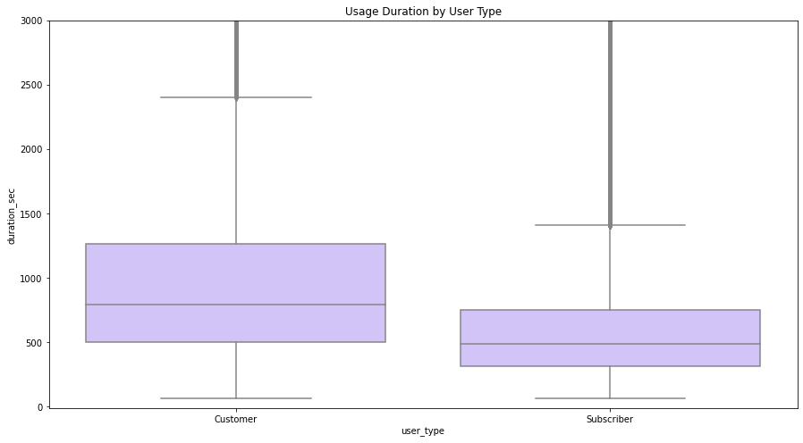

```python
plt.figure(figsize=(15,8))
plt.title('Usage Duration by User Type')
color = sb.color_palette("pastel")[4]
sb.boxplot(data=fb_clean, x='user_type', y='duration_sec', color=color);
plt.ylim([-15, 3000])
```

```python
# Average trip duration for Customer
fb_clean[cust].duration_sec.mean()
```

```
1432.465019126233
```

```python
# Average trip duration for Subscriber/Member

fb_clean[subs].duration_sec.mean()
```

```
640.2636782761825
```

This shows ride duration average for Customer is much higher than Subscriber, even though subscriber has higher number than customer.

## QUESTION 2: What is the dependency of trip durations on gender and on member type?

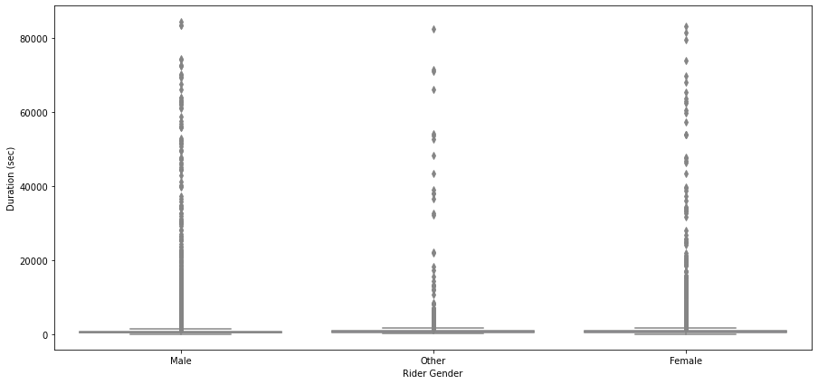

```python
#Lets plot a box plot to show the relationship between the gender and duration.
plt.figure(figsize = [15, 7])
color = sb.color_palette("pastel")[4]
sb.boxplot(data = fb_clean, x = 'member_gender', y = 'duration_sec', color =color)
plt.xlabel('Rider Gender')
plt.ylabel('Duration (sec)')
plt.show()
```

### Let us trim it to fit more on a box plot.

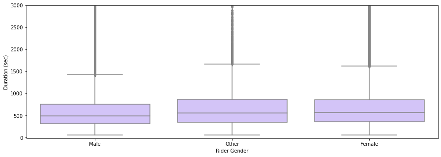

```python
plt.figure(figsize =[15, 5])
color = sb.color_palette("pastel")[4]
sb.boxplot(data = fb_clean, x = 'member_gender', y = 'duration_sec', color =color)
plt.ylim([-15, 3000])
plt.xlabel('Rider Gender')
plt.ylabel('Duration (sec)')
plt.show()
```

Though quantity of male riders are very high than other gender and female but we can see that higher percentage of female and other rides longer trips then males.

## QUESTION 3: What is the comparison between the user types, customer and subscriber?

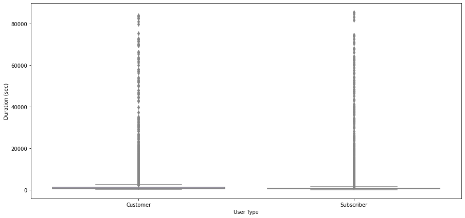

```python
#Let us compare the user type using duration on a box plot.
plt.figure(figsize = [15,7])
color = sb.color_palette("pastel")[4]
sb.boxplot(data =fb_clean, x = 'user_type', y = 'duration_sec', color = color)
plt.xlabel('User Type')
plt.ylabel('Duration (sec)')
plt.show()
```

### Let us trim it to fit more on a box plot.

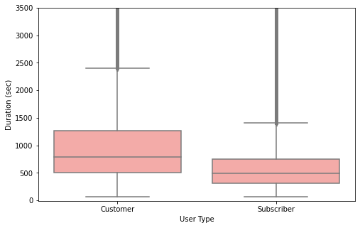

```python
plt.figure(figsize = [8, 5])
base_color = sb.color_palette("pastel")[3]
sb.boxplot(data = fb_clean, x = 'user_type', y = 'duration_sec', color = base_color)
plt.ylim([-10, 3500])
plt.xlabel('User Type')
plt.ylabel('Duration (sec)')
plt.show()
```

This clearly shows Customers have higher percenage of taking longer trips than subscribers.

## QUESTION 4: What is the correlation between Datetime and user type?

### Let us start by investigating Bike usage in a week

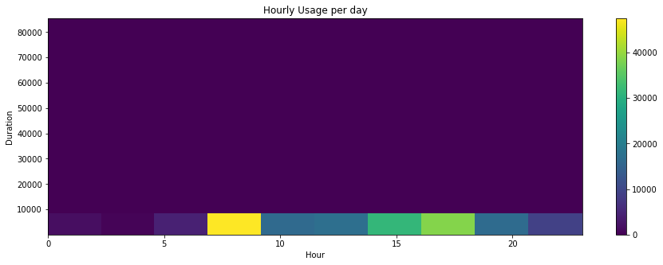

```python
# Let plot a heat map to see this.
plt.figure(figsize=(15, 5))
plt.hist2d(data= fb_clean, x='hour', y= 'duration_sec')
plt.colorbar()
plt.title('Hourly Usage per day')
plt.xlabel('Hour')
plt.ylabel('Duration')
```

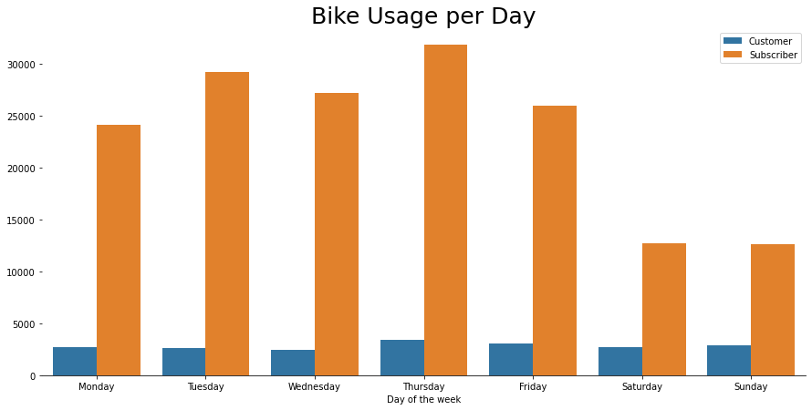

```python
#To check bike usage per day
plt.figure(figsize=(15,7))
plt.title('Bike Usage per Day', fontsize=25)
Bike = sb.countplot(data=fb_clean, x='start_day', order= day_name, hue='user_type')
Bike.set(xlabel='Day of the week', ylabel='')
sb.despine(fig=None, ax=None, top=True, right=True, left=True, bottom=False, offset=None, trim=False)
plt.gca().legend().set_title('');
```

#### This clearly shows that the use of this service for Subscribers is high on weekdays and decreases on weekends, but not so for Customers

### Let us also investigate Hour usage per day.

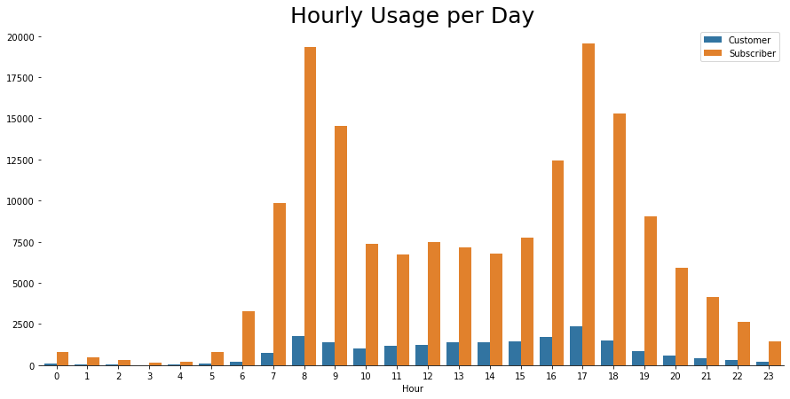

```python
plt.figure(figsize=(15, 7))
plt.title('Hourly Usage per Day', fontsize=25)
Bike2= sb.countplot(data=fb_clean, x='hour', hue='user_type')
Bike2.set(xlabel='Hour', ylabel='')
sb.despine(fig=None, ax=None, top=True, right=True, left=True, bottom=False, offset=None, trim=False)
plt.gca().legend().set_title('');
```

Most of the Subscribers use the service at peak hour of the day. It also shows that most of the Customers and Subscribers use the service between the hour of 7:00 to 19:00.

### Talk about some of the relationships you observed in this part of the investigation. How did the feature(s) of interest vary with other features in the dataset?

There is correlation between duration and user type.

### Did you observe any interesting relationships between the other features (not the main feature(s) of interest)?

Yes I did, Most Subscribers use the service at peak hour of the day.

## QUESTION 1: How is the two categorical measures gender and user type play into the relationship between trip duration and age?

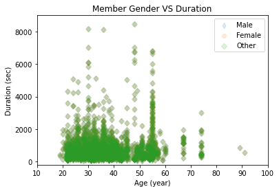

```python
#Plotting the member_gender on the same chart.
rider_markers = [['Male', 'd'],
                 ['Female', 'o'],
                 ['Other', 'D']]

for rider, marker in rider_markers:
    fb_clean_gender = fb_clean[fb_clean['member_gender'] == gender]
    plt.scatter((2019 -  fb_clean_gender['member_birth_year']), fb_clean_gender['duration_sec'], marker = marker, alpha=0.15)
plt.legend(['Male','Female','Other'])
plt.axis([10, 100, -200, 9000 ])
plt.title('Member Gender VS Duration')
plt.xlabel('Age (year)')
plt.ylabel('Duration (sec)')
plt.show()
```

I can hardly get anything out of this plot, so lets plot differently.

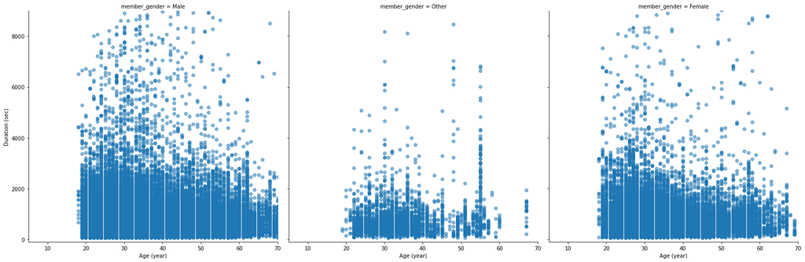

```python
#let us separate the gender into different sub plots.
fb_clean['age'] = (2019 - fb_clean['member_birth_year'])
riders = sb.FacetGrid(data = fb_clean, col = 'member_gender',
                      col_wrap = 4, size = 7,
                 xlim = [5, 70], ylim = [-100, 9000])
riders.map(plt.scatter, 'age', 'duration_sec', alpha=0.55)
riders.set_xlabels('Age (year)')
riders.set_ylabels('Duration (sec)')
warnings.simplefilter("ignore")
plt.show()
```

This shows rider of age 20 - 60 has more duration and We can see a jump in older age, close to 60 years of age.

### Let us check the user type as well.

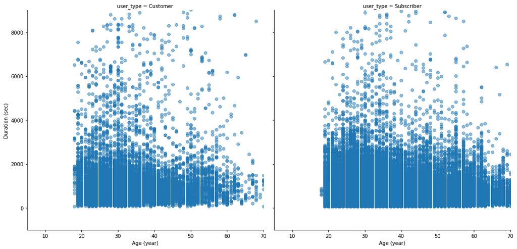

```python
fb_user = sb.FacetGrid(data =fb_clean, col = 'user_type',
                       col_wrap = 4, size = 7,
                 xlim = [5, 70], ylim = [-1000, 9000])
fb_user.map(plt.scatter, 'age', 'duration_sec', alpha=0.50)
fb_user.set_xlabels('Age (year)')
fb_user.set_ylabels('Duration (sec)')
warnings.simplefilter("ignore")
plt.show()
```

Both Customer and Subscriber are showing similer trends for age and trip duration. But there is changes to higher age for subscribers.

### Talk about some of the relationships you observed in this part of the investigation. Were there features that strengthened each other in terms of looking at your feature(s) of interest?

The number of higher duration trip is higher for male but percentage is higher for women and other, also other has one more peak at nearly the age of 60 years for higher duration time.

### Were there any interesting or surprising interactions between features?

Older age having the second peak is a shocker.

## Conclusions

In this investigation, I used all three types of exploration; Univariate, Bivariate, and Multivariate. Following them as their order helps me became more confident in the findings I discovered in the investigation.

## REFERENCES

1. Github
2. Stackoverflow
3. Google
4. Kaggle
5. Slack

```python
# Export cleaned dataframe to CSV file for slide deck
fb_clean.to_csv('fb_clean.csv', index=None)
fb_check = pd.read_csv('fb_clean.csv')

# Test
fb_check
```

[output not shown]